# Practical Machine Learning Project

Moath Abusirdaneh

August 8, 2018

# Introduction

Using devices such as Jawbone Up, Nike FuelBand, and Fitbit it is now possible to collect a large amount of data about personal activity relatively inexpensively. These type of devices are part of the quantified self movement ??? a group of enthusiasts who take measurements about themselves regularly to improve their health, to find patterns in their behavior, or because they are tech geeks. One thing that people regularly do is quantify how much of a particular activity they do, but they rarely quantify how well they do it.

In this project, your goal will be to use data from accelerometers on the belt, forearm, arm, and dumbell of 6 participants. They were asked to perform barbell lifts correctly and incorrectly in 5 different ways. More information is available from the website here: [http://groupware.les.inf.puc-rio.br/har] (see the section on the Weight Lifting Exercise Dataset).

## Loading Required Packages

```r
library(caret)
```

```r
library(ggplot2)
library(rattle)
```

## Importing Dataset

```r
train.dat <- read.csv("pml-training.csv")
dim(train.dat)
```

```
## [1] 19622   160
```

```r
test.dat <- read.csv("pml-testing.csv")
dim(test.dat)
```

```
## [1]  20 160
```

```r
# Viewing Strcuture
str(train.dat)
```

[output not shown]

[output cut: 86 more lines]

The training data set is made of 19622 observations on 160 columns. We can see that many columns have NA values or blank values on almost every observation. So we will remove them. Removing firts seven columns since these give information about the people who did the test, and also timestamps. We will not include them in the fitted model

```r
# Here we get the indexes of the columns having at least 90% of NA or blank values on the training dataset
indColToRemove <- which(colSums(is.na(train.dat)|train.dat=="")>0.9*dim(train.dat)[1])
trainClean <- train.dat[,-indColToRemove]
trainClean <- trainClean[,-c(1:7)]
dim(trainClean)
```

```
## [1] 19622    53
```

Applying the same for test dataset

```r
# Here we get the indexes of the columns having at least 90% of NA or blank values on the testing dataset
indColToRemove <- which(colSums(is.na(test.dat) |test.dat=="")>0.9*dim(test.dat)[1])
testClean <- test.dat[,-indColToRemove]
testClean <- testClean[,-c(1:7)]
dim(testClean)
```

```
## [1] 20 53
```

## Splitting Training dataset

Splitting the training dataset into two subgroups: training and validation sets, in order to apply three classification Models: **1- Classification tree** **2- Random forest** **3- Gradient boosting method**

```r
set.seed(12345)
inTrain <- createDataPartition(trainClean$classe, p=0.80, list = FALSE)
train.df <- trainClean[inTrain,]
validation.df <- trainClean[-inTrain,]
```

## Fitting the Classification Tree Model

**1. Fitting the classification tree with using 5-Folds cross validation**

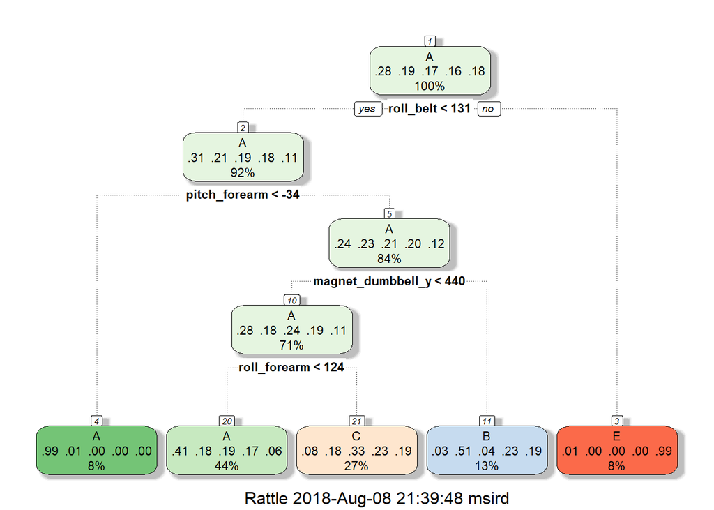

```r
model_tree <- train(classe ~ .,data = train.df,method="rpart", trControl= trainControl(method = "CV",
                                                                                   number = 5))
fancyRpartPlot(model_tree$finalModel)
```

**2.Generate Classification Tree predictions**

```r
tree_pred <- predict(model_tree,newdata=validation.df)
Tree_confMAT <- confusionMatrix(validation.df$classe,tree_pred)
Tree_confMAT$table
```

```
##           Reference
## Prediction    A    B    C    D    E
##          A 1008   15   89    0    4
##          B  331  246  182    0    0
##          C  297   21  366    0    0
##          D  305  106  232    0    0
##          E  111  101  191    0  318
```

```r
Tree_confMAT$overall[1]
```

```
##  Accuracy
## 0.4940097
```

We can see the calssification tree Accuracy is about 49%

## Fitting the Random Forest Model

**1. fitting the Random Forest with using 5-Folds cross validation**

```r
model_rf <- train(classe ~ .,data = train.df,method="rf", trControl= trainControl(method = "CV",
                                                                                     number = 5),
                  verbose=FALSE)
```

**2.Generate Random Forest predictions**

```r
rf_pred <- predict(model_rf,newdata=validation.df)
rf_confMAT <- confusionMatrix(validation.df$classe,rf_pred)
rf_confMAT$table
```

```
##           Reference
## Prediction    A    B    C    D    E
##          A 1116    0    0    0    0
##          B    4  754    1    0    0
##          C    0   12  672    0    0
##          D    0    0   15  628    0
##          E    0    0    0    1  720
```

```r
rf_confMAT$overall[1]
```

```
##  Accuracy
## 0.9915881
```

with Random Forest calssification tree we achieve Accuracy of **99%**. This is very good

**3. Showing Features Importance**

```r
MostImpVars <- varImp(model_rf)
MostImpVars
```

```
## rf variable importance
##
##   only 20 most important variables shown (out of 52)
##
##                      Overall
## roll_belt             100.00
## yaw_belt               76.68
## magnet_dumbbell_z      65.66
## magnet_dumbbell_y      60.38
## pitch_forearm          60.25
## pitch_belt             59.21
## magnet_dumbbell_x      51.16
## roll_forearm           48.64
## accel_dumbbell_y       44.15
## accel_belt_z           41.96
## magnet_belt_z          41.86
## roll_dumbbell          40.56
## magnet_belt_y          38.79
## accel_dumbbell_z       37.48
## roll_arm               34.49
## accel_forearm_x        32.82
## gyros_belt_z           29.40
## yaw_dumbbell           28.31
## accel_dumbbell_x       27.48
## total_accel_dumbbell   26.76
```

## Fitting the Gradient Boosting Model

**1. fitting the Gradient Boosting with using 5-Folds cross validation**

```r
model_gbm <- train(classe ~ .,data = train.df,method="gbm", trControl= trainControl(method = "CV",
                                                                                  number = 5),
                  verbose=FALSE)
```

**2.Generate Gradient Boosting predictions**

```r
gbm_pred <- predict(model_gbm,newdata=validation.df)
gbm_confMAT <- confusionMatrix(validation.df$classe,gbm_pred)
gbm_confMAT$table
```

```
##           Reference
## Prediction    A    B    C    D    E
##          A 1100   11    4    1    0
##          B   26  712   19    2    0
##          C    0   30  644    7    3
##          D    0    2   16  621    4
##          E    1    5    5    7  703
```

```r
gbm_confMAT$overall[1]
```

```
##  Accuracy
## 0.9635483
```

## Conclusion

Random Forest model is the best one. it will be used to predict the values of classe for the test data set.

```r
testPred <- predict(model_rf,newdata=testClean)
testPred
```

```
##  [1] B A B A A E D B A A B C B A E E A B B B
## Levels: A B C D E
```